# Spatiotemporal model with INLA assuming continuous time

### Step 3 - Priors and hyperparameters for temporal autocorrelation

```r
hSpec <- list(theta=list(prior='pccor1', param=c(0, 0.9)))
precPrior <- list(prior='pc.prec', param=c(1, 0.01))
```

### Step 4 - Index matrix

Here, we construct an “index matrix” used to extract the values of the latent spatial field at the observation locations.

```r
Field <- inla.spde.make.index("field", n.spde=SPDE$n.spde,
                              n.group = MeshTime$n)
```

### Step 5 - $A$ matrix

We need to construct an $A$ matrix. Recall from the lecture that the $A$ matrix is sometimes referred to as the *observation matrix* and includes the parameters used to construct model. The discrete temporal groups are defined here.

```r
# For estimation
A <- inla.spde.make.A(MeshSpace,
                      loc=st_coordinates(sugar),
                      group = year,
                      group.mesh = MeshTime)
```

**Important note** : The groups need to start at *1*.

### Step 6 - Organise the $A$ matrix into a list

```r
Alist <- as.list(rep(1,3))
Alist[[1]] <- A
```

### Step 7 - Organise the effects (spatial autocorrelation structure and explanatory variables)

```r
effect<- list(Field,
              bio1 =  climateScale[,1],
              bio2 = climateScale[,2])
```

### Step 8 - Build `stack`

Here, we build a `stack` that will be passed to the `inla` function. Note that this is a special version of `stack` especially designed for the INLA package.

```r
Stack <- inla.stack(data=list(tree = sugar$n_occ),
                    A = Alist,
                    effects = effect,
                    tag="basis")
```

### Step 9 - Building the model (Finally !)

```r
form <- tree ~ 0 + bio1 + bio2 +
        f(field, model=SPDE, group=field.group,
          control.group=list(model='ar1', hyper=hSpec))

model <- inla(form,
              data = inla.stack.data(Stack),
              family="nbinomial",
              control.family =list(link="log", hyper=list(theta=precPrior)),
              control.predictor=list(A=inla.stack.A(Stack),
                                                         compute=TRUE, link = 1),
              control.compute=list(waic=TRUE))
```

**Important note** : the argument `group` of the function `f()` refers to `group` defined in the object `Field`. As such, the “name” given in this object needs to be the name of the “field”.

### Study the output

```r
summary(model)
```

```
##
## Call:
##    c("inla(formula = form, family = \"nbinomial\", data =
##    inla.stack.data(Stack), ", " control.compute = list(waic = TRUE),
##    control.predictor = list(A = inla.stack.A(Stack), ", " compute = TRUE,
##    link = 1), control.family = list(link = \"log\", ", " hyper =
##    list(theta = precPrior)))")
## Time used:
##     Pre = 2.24, Running = 586, Post = 1.59, Total = 590
## Fixed effects:
##        mean    sd 0.025quant 0.5quant 0.975quant   mode kld
## bio1 -0.167 0.033     -0.232   -0.167     -0.102 -0.166   0
## bio2 -0.113 0.039     -0.190   -0.113     -0.036 -0.113   0
##
## Random effects:
##   Name     Model
##     field SPDE2 model
##
## Model hyperparameters:
##                                                        mean    sd 0.025quant
## size for the nbinomial observations (1/overdispersion) 1.61 0.021       1.57
## Range for field                                        4.22 0.507       3.43
## Stdev for field                                        1.86 0.147       1.61
## GroupRho for field                                     0.11 0.108      -0.11
##                                                        0.5quant 0.975quant
## size for the nbinomial observations (1/overdispersion)    1.608      1.651
## Range for field                                           4.148      5.402
## Stdev for field                                           1.852      2.187
## GroupRho for field                                        0.114      0.312
##                                                         mode
## size for the nbinomial observations (1/overdispersion) 1.607
## Range for field                                        3.950
## Stdev for field                                        1.816
## GroupRho for field                                     0.126
##
## Expected number of effective parameters(stdev): 339.66(9.38)
## Number of equivalent replicates : 45.89
##
## Watanabe-Akaike information criterion (WAIC) ...: 104404.74
## Effective number of parameters .................: 316.01
##
## Marginal log-Likelihood:  -52575.11
## Posterior marginals for the linear predictor and
##  the fitted values are computed
```

A noteworthy difference between this results and the one obtained with the discrete time spatiotemporal model is the temporal autocorrelation parameter, which is much smaller here. Because we know that from one year to another there is a strong autocorrelation, we know that there is a strong autocorrelation across time. So, by having mesh points fairly spread out in time and because it is known that there is variability in the distribution of sugar maples through time, it is not overly surprising that there less temporal autocorrelation with this model.

### Plot prediction maps

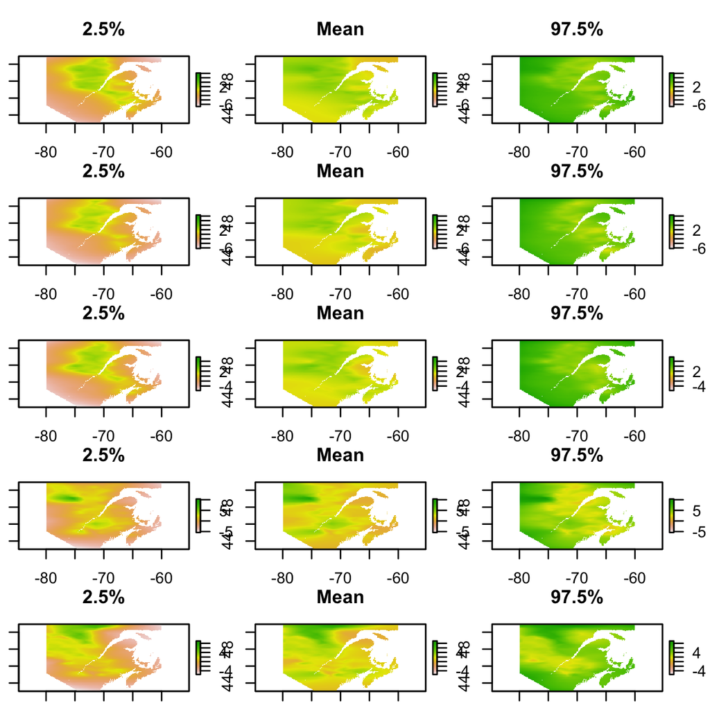

```r
# Dimention of the raster
rasterDim <- dim(climate)[1:2]

# Define basis of the map
mapBasis <- inla.mesh.projector(MeshSpace,
                               dims = rasterDim,
                               xlim = c(xmin(region), xmax(region)),
                               ylim = c(ymin(region), ymax(region)),
                               crs = crs(region))

# Calculate prediction
mapMean <- vector("list", length = 5)
map.025 <- vector("list", length = 5)
map.975 <- vector("list", length = 5)

for(i in 1:5){
  mapMean[[i]] <- inla.mesh.project(mapBasis,
                               model$summary.random$field$mean[1:SPDE$n.spde + (i - 1) * SPDE$n.spde])
  map.025[[i]] <- inla.mesh.project(mapBasis,
                               model$summary.random$field$`0.025quant`[1:SPDE$n.spde + (i - 1) * SPDE$n.spde])
  map.975[[i]] <- inla.mesh.project(mapBasis,
                               model$summary.random$field$`0.975quant`[1:SPDE$n.spde + (i - 1) * SPDE$n.spde])
}

# Transform map into a raster
rasterMean <- brick(climate, nl = 5)
raster.025 <- brick(climate, nl = 5)
raster.975 <- brick(climate, nl = 5)

for(i in 1:5){
  values(rasterMean)[,i] <- as.vector(t(mapMean[[i]]))
  values(raster.025)[,i] <- as.vector(t(map.025[[i]]))
  values(raster.975)[,i] <- as.vector(t(map.975[[i]]))
}

# Mask the region
rasterMeanMask <- mask(rasterMean, region)
raster.025Mask <- mask(raster.025, region)
raster.975Mask <- mask(raster.975, region)

# Plot the results
par(mfrow = c(5,3), mar = c(1,1,3,1))
for(i in 1:5){
  plot(raster.025Mask[[i]], zlim = range(values(raster.025Mask[[i]]),
                                values(rasterMeanMask[[i]]),
                                values(raster.975Mask[[i]]), na.rm = TRUE),
       main = "2.5%")

  plot(rasterMeanMask[[i]], zlim = range(values(raster.025Mask[[i]]),
                                values(rasterMeanMask[[i]]),
                                values(raster.975Mask[[i]]), na.rm = TRUE),
       main = "Mean")

  plot(raster.975Mask[[i]], zlim = range(values(raster.025Mask[[i]]),
                                values(rasterMeanMask[[i]]),
                                values(raster.975Mask[[i]]), na.rm = TRUE),
       main = "97.5%")
}
```

Note that this code allows us to draw prediction maps only at the temporal mesh points.